# Assignment 14: Writing a function - Loop

*How to do it?*:

- Open the Rmarkdown file of this assignment (link) in Rstudio.
- Right under each **question**, insert a code chunk (you can use the hotkey `Ctrl + Alt + I` to add a code chunk) and code the solution for the question.
- `Knit` the rmarkdown file (hotkey: `Ctrl + Alt + K`) to export an html.
- Publish the html file to your Githiub Page.

*Submission*: Submit the link on Github of the assignment to Canvas

## Question 1

1. Write the following function. Give examples to test your function.
- Input: a data frame
- Output: a data frame with all the missing of numeric variables replaced by the associated means.

Hint: [Similar function](https://bryantstats.github.io/math421/gganimate/18_writing_functions.html#28)

### Solution

The loop checks each column. For a numeric column, it replaces `NA` with the mean of the observed values. Non-numeric columns stay unchanged.

```r
numeric_impute <- function(d) {
  for (i in seq_along(d)) {
    if (is.numeric(d[[i]])) {
      # A completely missing column has no observed mean.
      if (any(!is.na(d[[i]]))) {
        column_mean <- mean(d[[i]], na.rm = TRUE)
        d[[i]][is.na(d[[i]])] <- column_mean
      }
    }
  }
  return(d)
}
```

```r
missing_data <- data.frame(
  age = c(20, NA, 30, 40, NA, 50),
  spending = c(100, 120, NA, 160, 180, NA),
  group = c("A", NA, "A", "B", "A", NA),
  region = factor(c("North", "North", NA, "South", "North", NA)),
  member = c(TRUE, NA, TRUE, FALSE, TRUE, NA)
)

missing_data
```

```
##   age spending group region member
## 1  20      100     A  North   TRUE
## 2  NA      120  <NA>  North     NA
## 3  30       NA     A   <NA>   TRUE
## 4  40      160     B  South  FALSE
## 5  NA      180     A  North   TRUE
## 6  50       NA  <NA>   <NA>     NA
```

```r
numeric_result <- numeric_impute(missing_data)
numeric_result
```

```
##   age spending group region member
## 1  20      100     A  North   TRUE
## 2  35      120  <NA>  North     NA
## 3  30      140     A   <NA>   TRUE
## 4  40      160     B  South  FALSE
## 5  35      180     A  North   TRUE
## 6  50      140  <NA>   <NA>     NA
```

```r
colSums(is.na(numeric_result))
```

```
##      age spending    group   region   member
##        0        0        2        2        2
```

```r
# The observed age mean is 35, and the observed spending mean is 140.
stopifnot(all(numeric_result$age[c(2, 5)] == 35),
          all(numeric_result$spending[c(3, 6)] == 140),
          identical(numeric_result$group, missing_data$group))
```

The numeric columns now have no missing values. The categorical and logical columns still have their original missing values, as intended. If a column is entirely missing, its mean cannot be calculated, so those values remain missing.

## Question 2

2. Write the following function. Give examples to test your function.
- Input: a data frame
- Output: a data frame with all the missing of variables replaced by the associated means (for numeric variables) or modes (for non-numeric variables).

Hint: Use If-statement to combine the function in Problem 1 and the function in [this example](https://bryantstats.github.io/math421/gganimate/18_writing_functions.html#28)

### Solution

I use a helper function to find the most frequent observed value, which is the statistical mode. Then an `if` statement chooses mean imputation for numeric columns and mode imputation for the other columns.

```r
mode_impute <- function(x) {
  observed <- x[!is.na(x)]
  if (length(observed) == 0) return(x)

  counts <- table(observed)
  mode_name <- names(counts)[which.max(counts)]

  # Take the value from the original vector to preserve its type.
  mode_value <- observed[match(mode_name, as.character(observed))]
  x[is.na(x)] <- mode_value
  return(x)
}

all_impute <- function(d) {
  for (i in seq_along(d)) {
    if (is.numeric(d[[i]])) {
      if (any(!is.na(d[[i]]))) {
        d[[i]][is.na(d[[i]])] <- mean(d[[i]], na.rm = TRUE)
      }
    } else {
      d[[i]] <- mode_impute(d[[i]])
    }
  }
  return(d)
}
```

```r
complete_result <- all_impute(missing_data)
complete_result
```

```
##   age spending group region member
## 1  20      100     A  North   TRUE
## 2  35      120     A  North   TRUE
## 3  30      140     A  North   TRUE
## 4  40      160     B  South  FALSE
## 5  35      180     A  North   TRUE
## 6  50      140     A  North   TRUE
```

```r
colSums(is.na(complete_result))
```

```
##      age spending    group   region   member
##        0        0        0        0        0
```

```r
stopifnot(!anyNA(complete_result),
          all(complete_result$group[c(2, 6)] == "A"),
          all(as.character(complete_result$region[c(3, 6)]) == "North"),
          all(complete_result$member[c(2, 6)]),
          is.factor(complete_result$region),
          is.logical(complete_result$member))
```

The modes are `A`, `North`, and `TRUE`. The factor and logical columns keep their types. If categories tie, the first tied category in `table()` order is used. An entirely missing column stays missing because it has no observed mean or mode. These functions return a new data frame; the original `missing_data` still contains its missing values.

```r
all_missing <- data.frame(
  number = c(NA_real_, NA_real_),
  category = c(NA_character_, NA_character_)
)
all_impute(all_missing)
```

```
##   number category
## 1     NA     <NA>
## 2     NA     <NA>
```

```r
stopifnot(identical(all_impute(all_missing), all_missing))
```

## Question 3

3. Write the following function. Give examples to test your function.
- Input: a data frame
- Output: Bar plots of all non-numeric variables

Hint: [Similar function](https://bryantstats.github.io/math421/gganimate/18_writing_functions.html#33)

### Solution

This function loops through the columns and prints a bar plot whenever the column is non-numeric. `print()` displays each plot inside the loop. It also returns the plots invisibly in a list so I can check their number.

```r
bar_plot <- function(d) {
  plots <- list()
  for (i in seq_along(d)) {
    if (!is.numeric(d[[i]])) {
      p <- ggplot(d, aes(x = .data[[names(d)[i]]])) +
        geom_bar(fill = "steelblue") +
        labs(title = paste("Counts of", names(d)[i]),
             x = names(d)[i], y = "Count") +
        theme_minimal()
      print(p)
      plots[[names(d)[i]]] <- p
    }
  }
  return(invisible(plots))
}
```

The following small, made-up dataset is used to test the plotting functions. It has three numeric columns and two categorical columns.

```r
plot_data <- data.frame(
  age = c(20, 22, 25, 27, 30, 32, 35, 37, 40, 42, 45, 47),
  spending = c(120, 100, 150, 180, 160, 210, 230, 200, 240, 260, 250, 290),
  score = c(60, 65, 64, 70, 72, 75, 74, 80, 81, 85, 84, 88),
  group = factor(rep(c("A", "B"), 6)),
  region = rep(c("North", "South", "West"), each = 4)
)
plot_data
```

```
##    age spending score group region
## 1   20      120    60     A  North
## 2   22      100    65     B  North
## 3   25      150    64     A  North
## 4   27      180    70     B  North
## 5   30      160    72     A  South
## 6   32      210    75     B  South
## 7   35      230    74     A  South
## 8   37      200    80     B  South
## 9   40      240    81     A   West
## 10  42      260    85     B   West
## 11  45      250    84     A   West
## 12  47      290    88     B   West
```

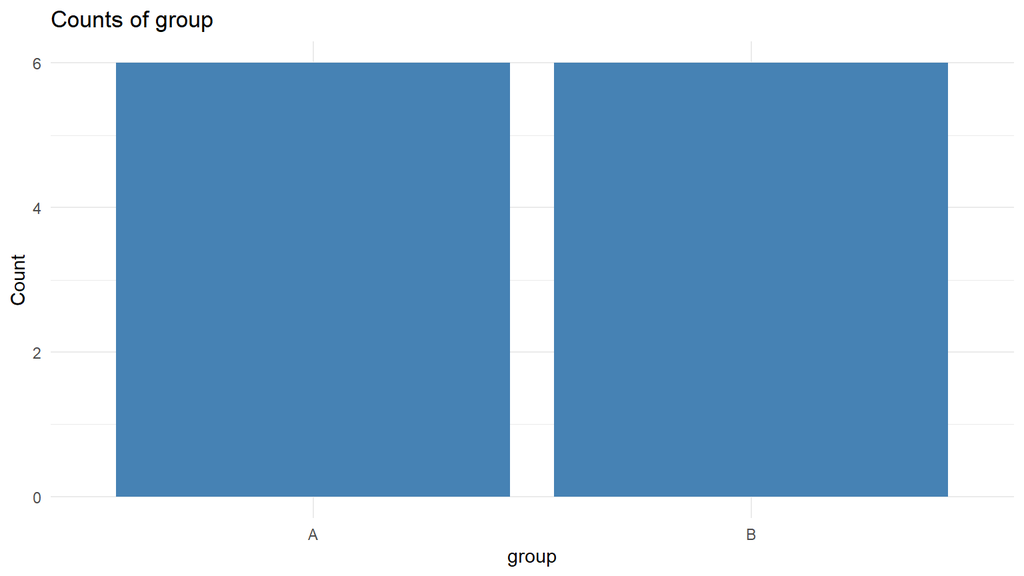

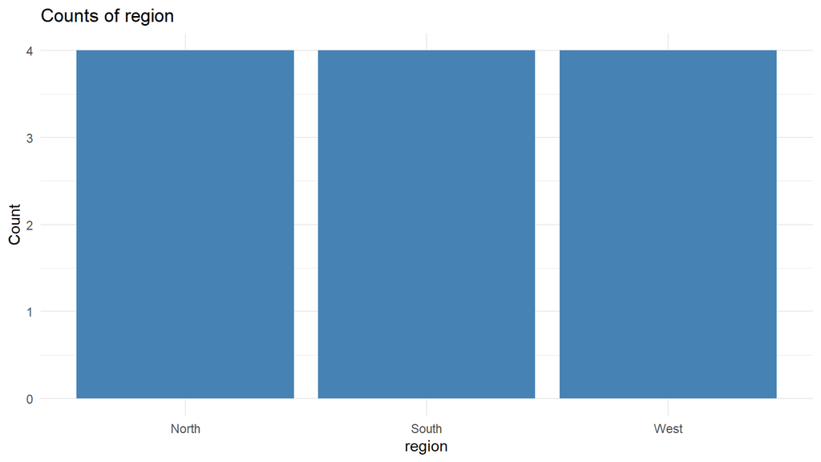

```r
single_bars <- bar_plot(plot_data)
```

```r
length(single_bars)
```

```
## [1] 2
```

```r
stopifnot(length(single_bars) == 2)
```

There are two plots: one for `group` and one for `region`. Each bar counts the rows in that category.

## Question 4

4. Write the following function. Give examples to test your function.
- Input: a data frame
- Output: all possible the bar plots of a non-numeric variable filled by a non-numeric variable.

Hint: [Similar function](https://bryantstats.github.io/math421/gganimate/18_writing_functions.html#40)

### Solution

The two loops consider every pair of columns. The `if` statement keeps two distinct non-numeric columns. Swapping the x and fill variables gives a different layout, so this version shows both directions.

```r
bar_plot2 <- function(d) {
  plots <- list()
  for (i in seq_along(d)) {
    for (j in seq_along(d)) {
      if (i != j && !is.numeric(d[[i]]) && !is.numeric(d[[j]])) {
        p <- ggplot(d, aes(x = .data[[names(d)[i]]],
                           fill = .data[[names(d)[j]]])) +
          geom_bar(position = "dodge") +
          labs(title = paste(names(d)[i], "filled by", names(d)[j]),
               x = names(d)[i], y = "Count", fill = names(d)[j]) +
          theme_minimal()
        print(p)
        plot_name <- paste(names(d)[i], names(d)[j], sep = "_by_")
        plots[[plot_name]] <- p
      }
    }
  }
  return(invisible(plots))
}
```

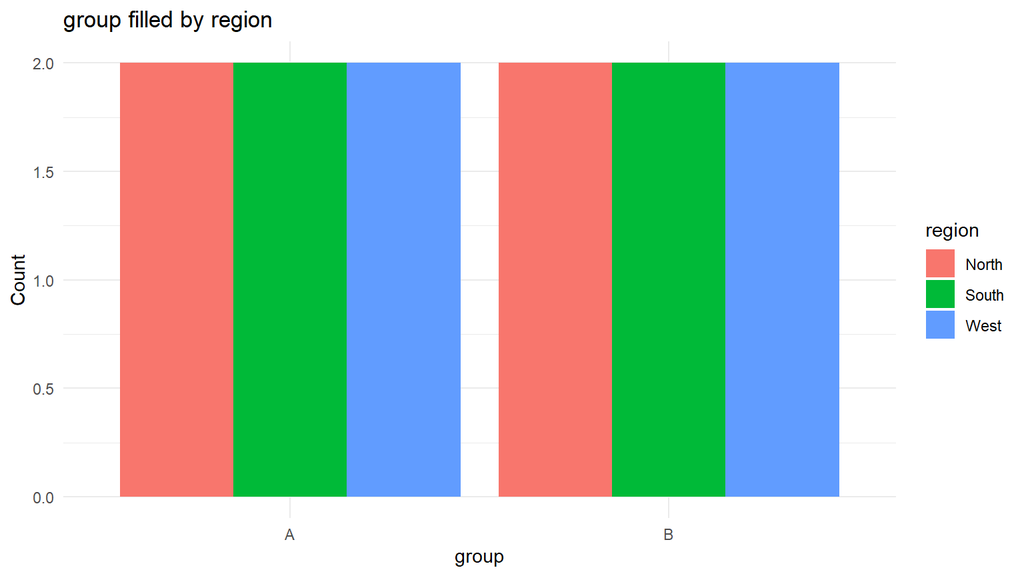

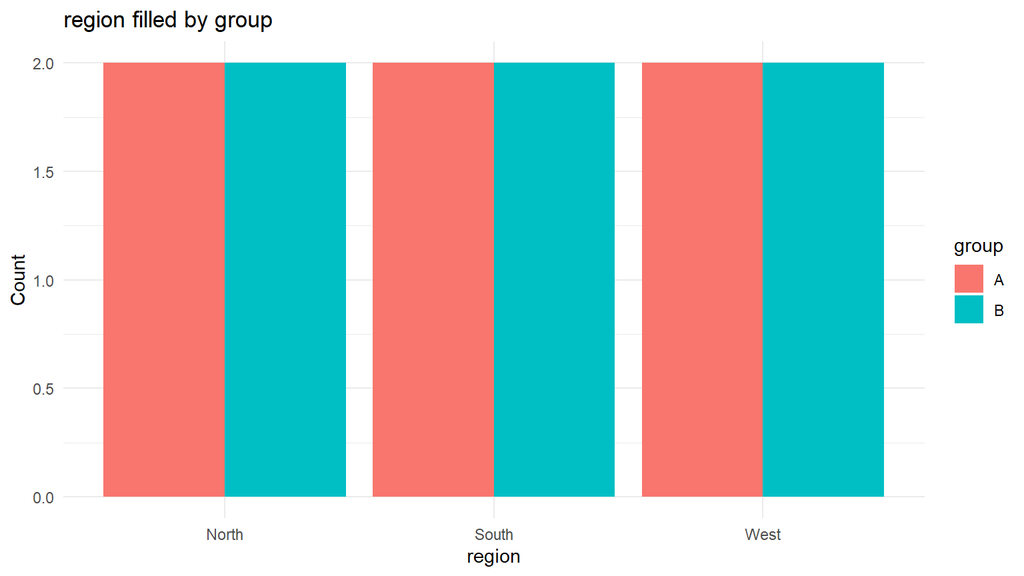

```r
grouped_bars <- bar_plot2(plot_data)
```

```r
names(grouped_bars)
```

```
## [1] "group_by_region" "region_by_group"
```

```r
length(grouped_bars)
```

```
## [1] 2
```

```r
stopifnot(length(grouped_bars) == 2)
```

The plots show `group` filled by `region` and `region` filled by `group`. With two categorical columns there are `2 * (2 - 1) = 2` such plots.

## Question 5

5. Write the following function. Give examples to test your function.
- Input: a data frame
- Output:
  - all possible the bar plots of a non-numeric variable filled by a non-numeric variable.
  - all possible the density plots of a numeric variable colored by a non-numeric variable
  - all possible the scatter plots.

Hint: Combine [this function](https://bryantstats.github.io/math421/gganimate/18_writing_functions.html#37), [this function](https://bryantstats.github.io/math421/gganimate/18_writing_functions.html#40), and the function in Question 4. One way to combine is creating a new function, `quick_plot`, and call these three functions within `quick_plot`.

### Solution

I combine `bar_plot2()` with a density function and a scatterplot function. The density function checks every numeric/categorical combination, regardless of column order. The scatterplot function uses `i < j` so each pair of numeric columns is plotted once.

```r
density_plot2 <- function(d) {
  plots <- list()
  for (i in seq_along(d)) {
    for (j in seq_along(d)) {
      if (is.numeric(d[[i]]) && !is.numeric(d[[j]])) {
        p <- ggplot(d, aes(x = .data[[names(d)[i]]],
                           color = .data[[names(d)[j]]])) +
          geom_density(na.rm = TRUE) +
          labs(title = paste(names(d)[i], "by", names(d)[j]),
               x = names(d)[i], y = "Density", color = names(d)[j]) +
          theme_minimal()
        print(p)
        plot_name <- paste(names(d)[i], names(d)[j], sep = "_by_")
        plots[[plot_name]] <- p
      }
    }
  }
  return(invisible(plots))
}

scatter_plot <- function(d) {
  plots <- list()
  for (i in seq_along(d)) {
    for (j in seq_along(d)) {
      if (i < j && is.numeric(d[[i]]) && is.numeric(d[[j]])) {
        p <- ggplot(d, aes(x = .data[[names(d)[i]]],
                           y = .data[[names(d)[j]]])) +
          geom_point(color = "steelblue", na.rm = TRUE) +
          labs(title = paste(names(d)[i], "and", names(d)[j]),
               x = names(d)[i], y = names(d)[j]) +
          theme_minimal()
        print(p)
        plot_name <- paste(names(d)[i], names(d)[j], sep = "_and_")
        plots[[plot_name]] <- p
      }
    }
  }
  return(invisible(plots))
}

quick_plot <- function(d) {
  bar_plots <- bar_plot2(d)
  density_plots <- density_plot2(d)
  scatter_plots <- scatter_plot(d)
  return(invisible(list(bars = bar_plots, densities = density_plots,
                        scatters = scatter_plots)))
}
```

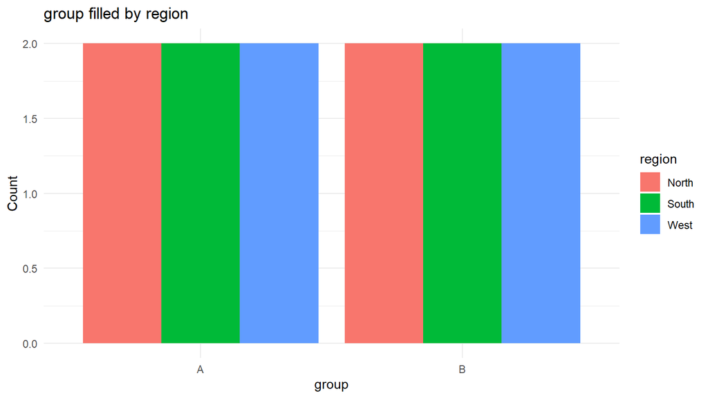

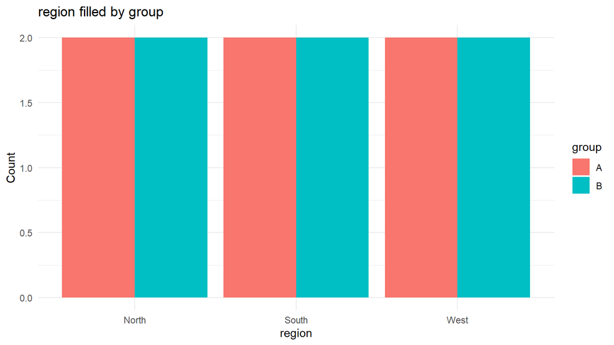

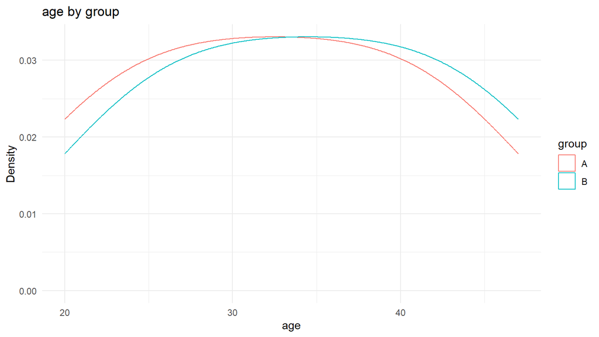

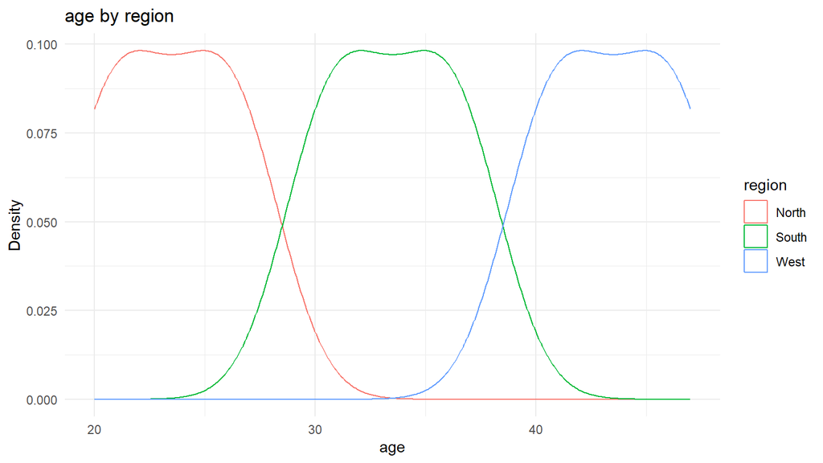

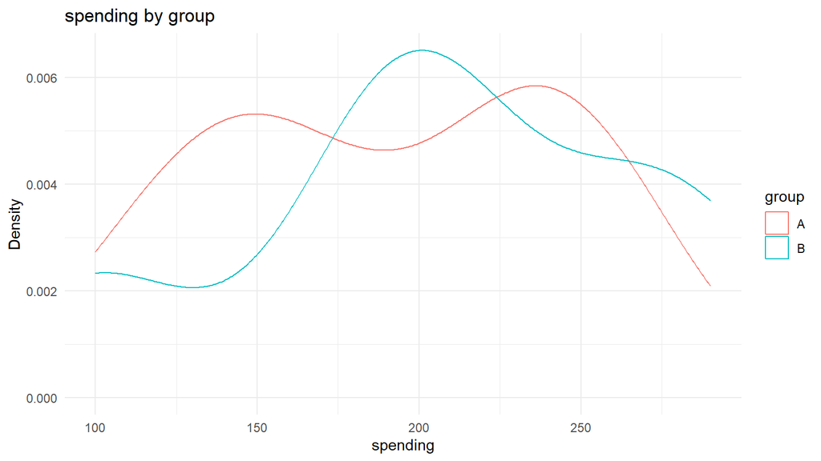

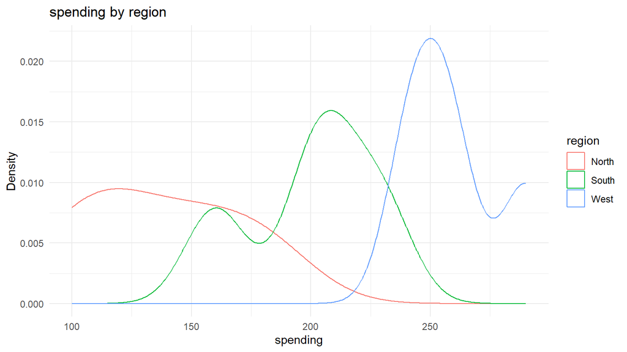

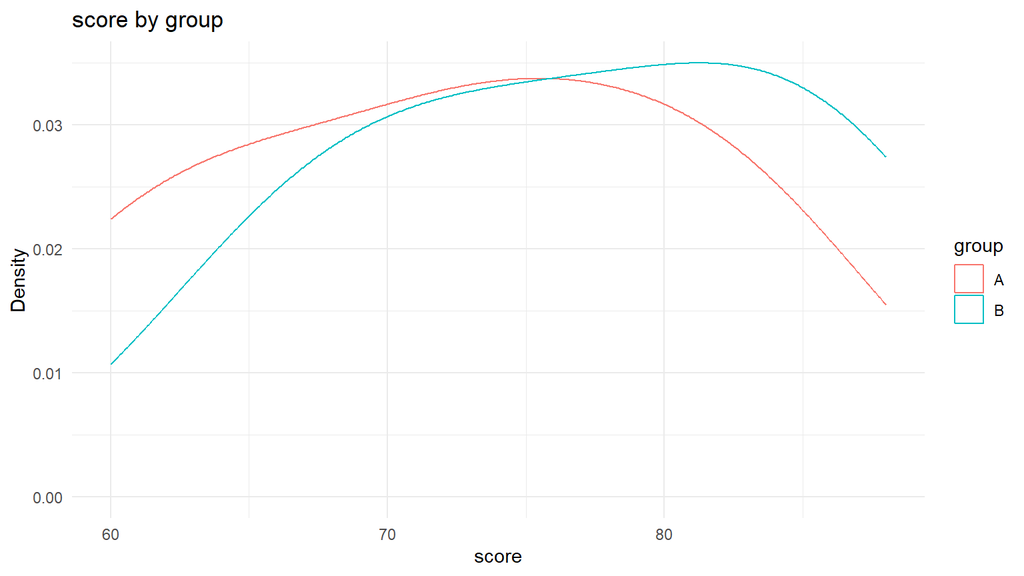

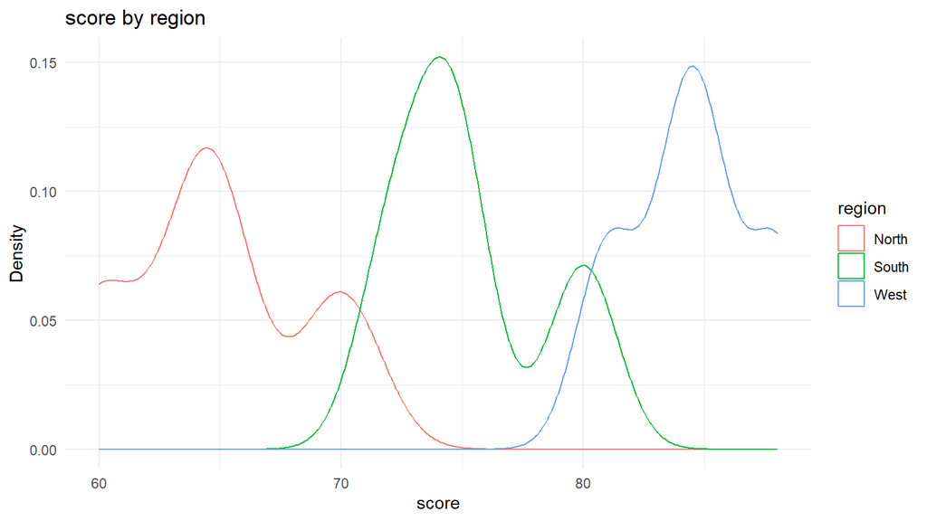

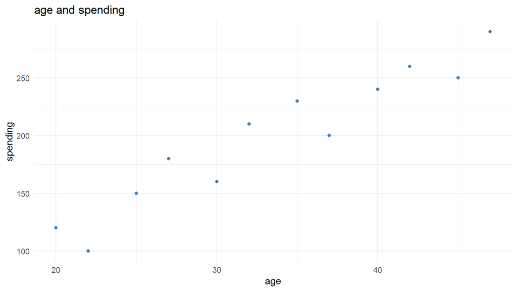

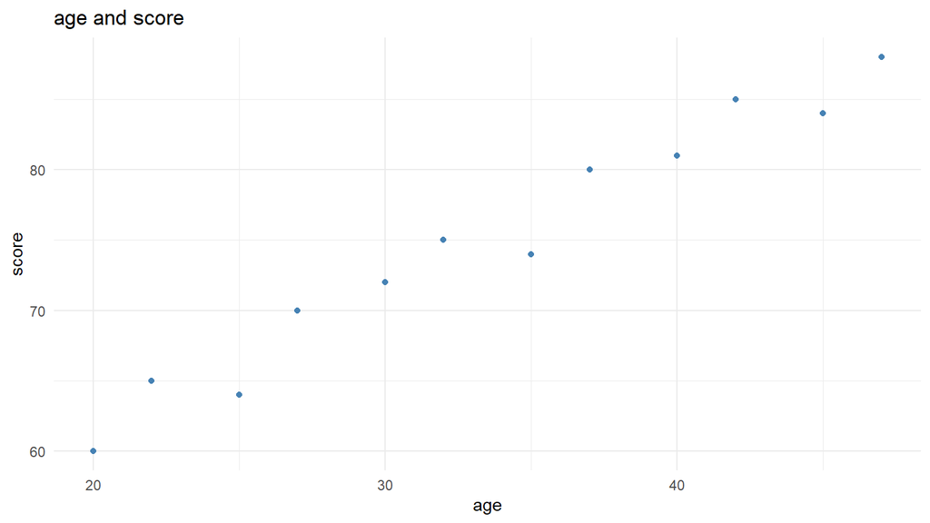

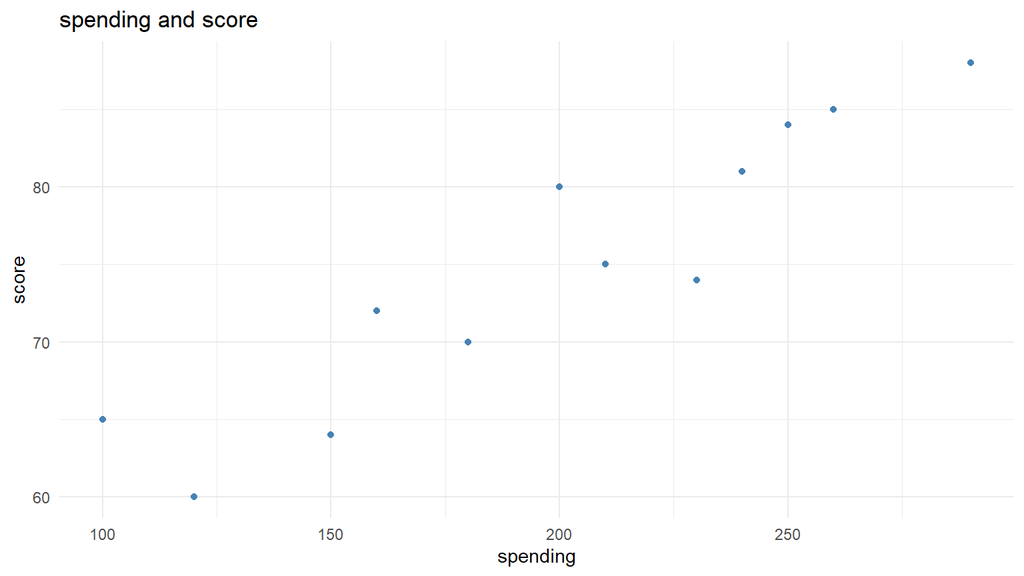

```r
all_plots <- quick_plot(plot_data)
```

```r
c(Bars = length(all_plots$bars),
  Densities = length(all_plots$densities),
  Scatters = length(all_plots$scatters))
```

```
##      Bars Densities  Scatters
##         2         6         3
```

```r
stopifnot(length(all_plots$bars) == 2,
          length(all_plots$densities) == 6,
          length(all_plots$scatters) == 3)
```

The combined function prints **11 plots**. There are 2 grouped bar plots, `3 * 2 = 6` density plots, and `3 * (3 - 1) / 2 = 3` scatterplots. The density examples have at least four observations per category.

The numeric plots use numeric columns as stored in the input data. A categorical variable coded with numbers should be converted to a factor before calling these functions. The `.data[[...]]` notation selects a column using its name inside a loop.